# Case Study

## Bike rental demand

### Dataset

This data set has been obtained from https://www.kaggle.com/competitions/bike-sharing-demand/data?select=train.csv. The data is about the rent of bikes per hour during two years. All the information related with the variables is in the link provided before.

```r
rm(list=ls())
setwd("C:/Users/dtori/OneDrive/Escritorio/UC3M/Bayesian/Case study")
data = read.csv("bikes.csv")
attach(data)
```

Our goals are: - Obtaining a posterior distribution for the number of total rentals. - Be able to predict the number of bike rentals.

### Exploratory data analysis

Firstly we need to perform and EDA to understand the data we are working with.

```r
summary(data)
```

```
##    datetime             season         holiday          workingday
##  Length:10886       Min.   :1.000   Min.   :0.00000   Min.   :0.0000
##  Class :character   1st Qu.:2.000   1st Qu.:0.00000   1st Qu.:0.0000
##  Mode  :character   Median :3.000   Median :0.00000   Median :1.0000
##                     Mean   :2.507   Mean   :0.02857   Mean   :0.6809
##                     3rd Qu.:4.000   3rd Qu.:0.00000   3rd Qu.:1.0000
##                     Max.   :4.000   Max.   :1.00000   Max.   :1.0000
##     weather           temp           atemp          humidity
##  Min.   :1.000   Min.   : 0.82   Min.   : 0.76   Min.   :  0.00
##  1st Qu.:1.000   1st Qu.:13.94   1st Qu.:16.66   1st Qu.: 47.00
##  Median :1.000   Median :20.50   Median :24.24   Median : 62.00
##  Mean   :1.418   Mean   :20.23   Mean   :23.66   Mean   : 61.89
##  3rd Qu.:2.000   3rd Qu.:26.24   3rd Qu.:31.06   3rd Qu.: 77.00
##  Max.   :4.000   Max.   :41.00   Max.   :45.45   Max.   :100.00
##    windspeed          casual         registered        count
##  Min.   : 0.000   Min.   :  0.00   Min.   :  0.0   Min.   :  1.0
##  1st Qu.: 7.002   1st Qu.:  4.00   1st Qu.: 36.0   1st Qu.: 42.0
##  Median :12.998   Median : 17.00   Median :118.0   Median :145.0
##  Mean   :12.799   Mean   : 36.02   Mean   :155.6   Mean   :191.6
##  3rd Qu.:16.998   3rd Qu.: 49.00   3rd Qu.:222.0   3rd Qu.:284.0
##  Max.   :56.997   Max.   :367.00   Max.   :886.0   Max.   :977.0
```

We can see some variables should be converted to factors. These variables are season, holiday,workingday and weather. In addition this data set does not have missing values.

```r
data$season = as.factor(season)
data$holiday = as.factor(holiday)
data$workingday = as.factor(workingday)
data$weather = as.factor(weather)
```

We also have to deal with the datetime variable as it is providing the day and the hour of the number of rentals, but the day only provides us information that is given by the holiday and workingday variables. This means that the only useful information about datetime variable is the hour. We will create a new variable with the hour.

```r
hour=format(as.POSIXct(data$datetime), format = "%H")
data$datetime=as.factor(hour)
```

Now we have to check if there are outliers, and if we have, we will remove them.

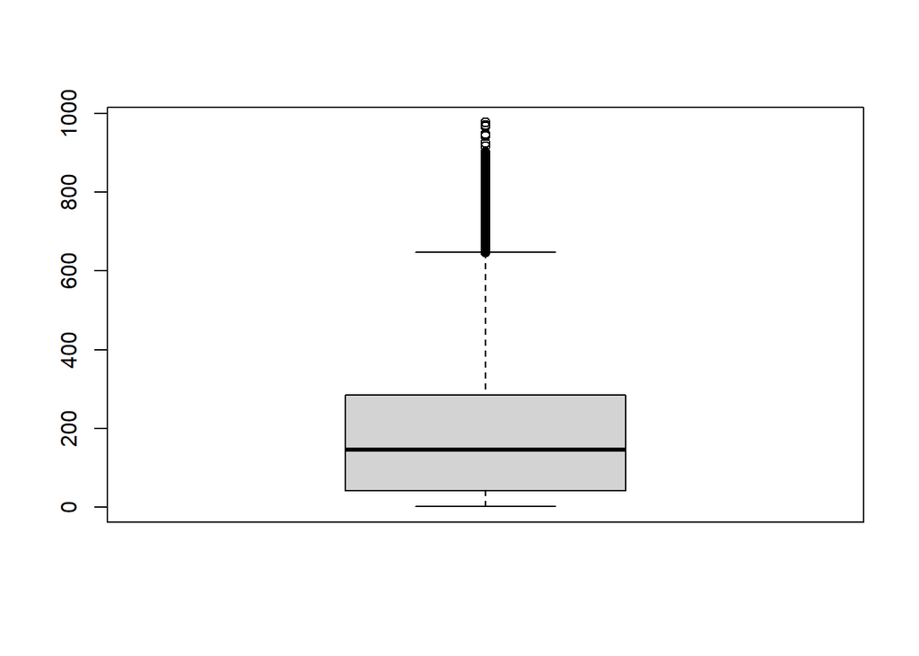

```r
boxplot(data$count)
```

```r
quantiles = quantile(data$count, probs=c(.25, .75))
IQR = IQR(data$count)

Lower = quantiles[1] - 1.5*IQR
Upper = quantiles[2] + 1.5*IQR

data = subset(data, data$count > Lower & data$count < Upper)
```

### Posterior distribution for the number of total rentals

```r
summary(data$count)
```

```
##    Min. 1st Qu.  Median    Mean 3rd Qu.    Max.
##     1.0    40.0   138.0   175.6   270.0   646.0
```

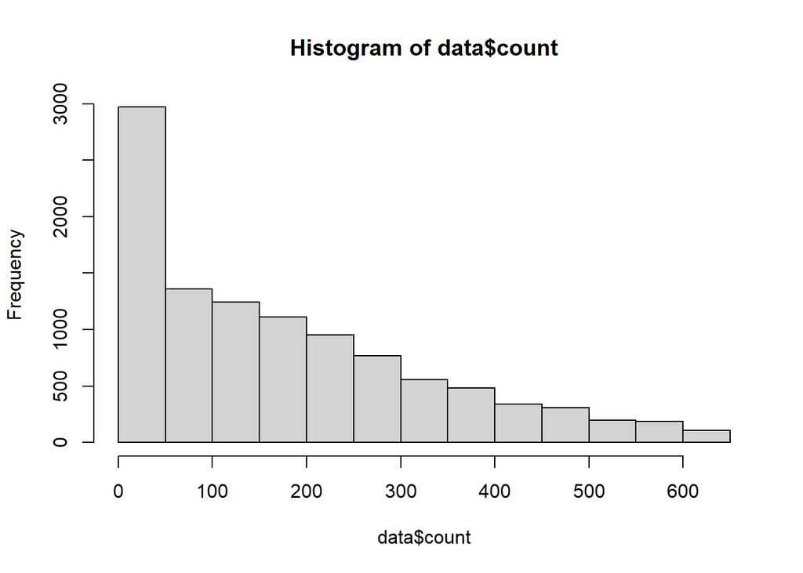

```r
hist(data$count)
```

We can see that count variable is skewed right and as we have the number of bike rentals per hour a Poisson distribution can be assumed.

$$P(X = k) =
\frac{e^{-\lambda}\lambda^k}{k!}$$
As we have assumed a Poisson distribution we can use a gamma distribution as a conjugate prior.
$$\lambda \sim \text{Gamma}(a,b)$$
The likelihood of a poisson distribution is:
$$f(data|\lambda) \propto \lambda^{\sum_{i=1}^n
x_i} e^{-n\lambda}$$
Applying the Bayes theorem we obtain the posterior distribution for λ.
$$λ|data ∼
Gamma(a +\sum_{i=1}^n x_i, b + n).$$
We do not have expert’s opinion so we can assume non informative prior.

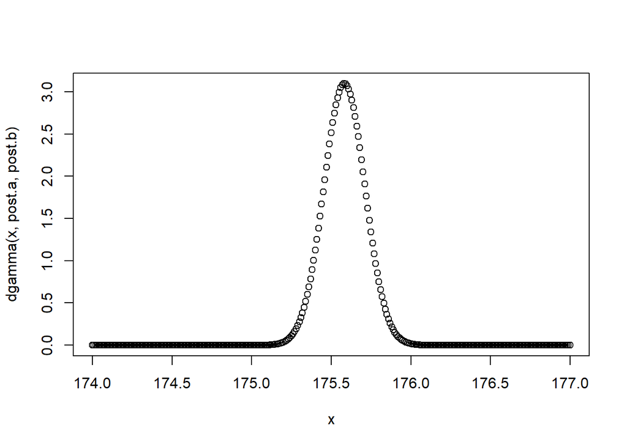

```r
a=0.01
b=0.01
post.a=a+sum(data$count)
post.b=b+nrow(data)
x=seq(174,177,0.01)
plot(x,dgamma(x,post.a,post.b))
```

The posterior mean:

```r
(post.a + sum(data$count)) / (post.b + nrow(data))
```

```
## [1] 175.5834
```

95% credible interval for the mean expected number of rentals per hour:

```r
 c(qgamma(0.025,post.a,post.b),qgamma(0.975,post.a,post.b))
```

```
## [1] 175.3310 175.8359
```

We can also obtain the predictive distribution:
$$\Pr(X=x|data) = {\int_0^\infty \Pr(X=x|\lambda)
\Pr(\lambda|data) \, d\lambda}$$
After computations we obtain:

$$\Pr(X=x|data) = \frac{(b+n)^{a
+\sum_{i=1}^n x_i}}{x!\Gamma(a +\sum_{i=1}^n x_i)} \frac{\Gamma(a
+x+\sum_{i=1}^n x_i)}{(b+n+1)^{a +x+\sum_{i=1}^n x_i}}$$

With this we are able to predict the probability of the number of rentals for the next hour, but in practice as the sum of count variable is very large we obtain an indetermination so we need to use another approach to be able to predict the number of bike rentals per hour.

We can apply Monte Carlo to obtain a sample of the predictive distribution for the next hour.

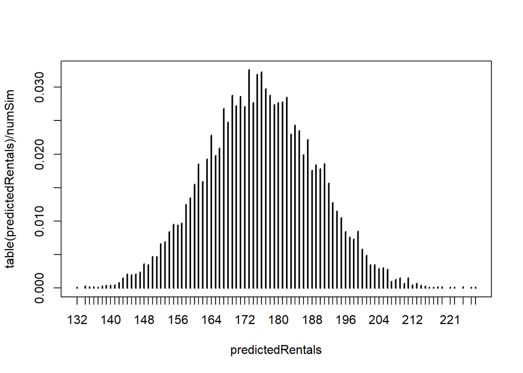

```r
numSim=10000
predictedRentals = NULL
for (i in 1:numSim) {
  lambdaMC=rgamma(1,post.a,post.b)
  predictedRentals[i]=rpois(1,lambdaMC)
  }
plot(table(predictedRentals)/numSim)
```

```r
mean(predictedRentals)
```

```
## [1] 175.8234
```

We can obtain a 95% confidence interval for our prediction.

```r
c(quantile(predictedRentals,0.025),quantile(predictedRentals,0.975))
```

```
##  2.5% 97.5%
##   150   201
```

As the response variable follows a Poisson distribution and we have covariates of the number of rentals, we can also implement Bayesian Poisson regression.

### Bayesian Poisson regression

We can make some plots that will be useful to see what are the covariates that are more correlated with count.

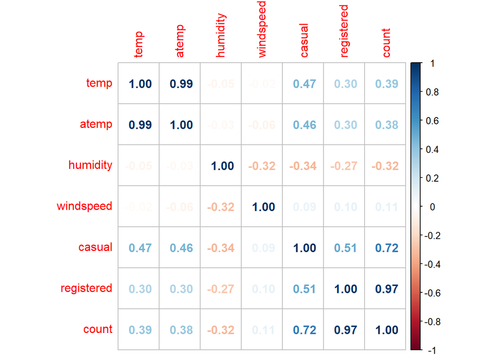

```r
library(corrplot)
corrplot(cor(data[,6:12]), method = 'number')
```

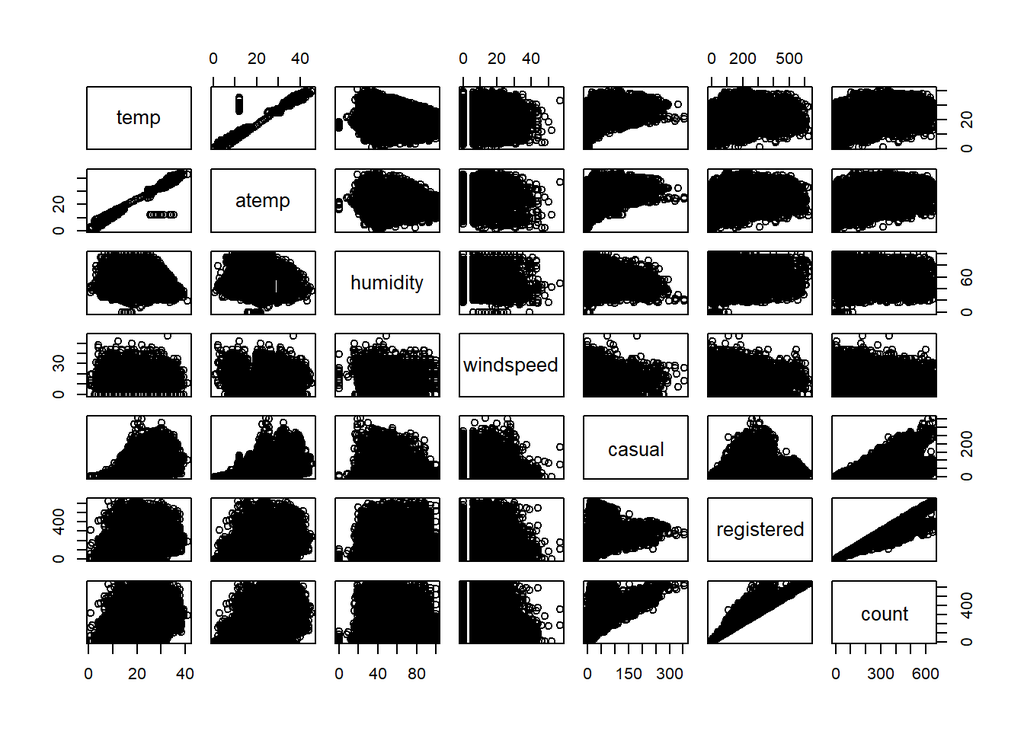

```r
pairs(data[,6:12])
```

We can see that registered and casual have strong positive correlation with count.

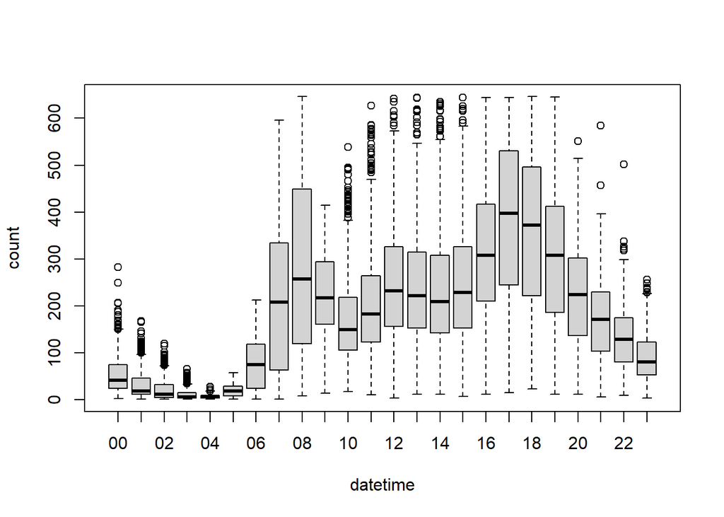

```r
attach(data)
boxplot(count~datetime)
```

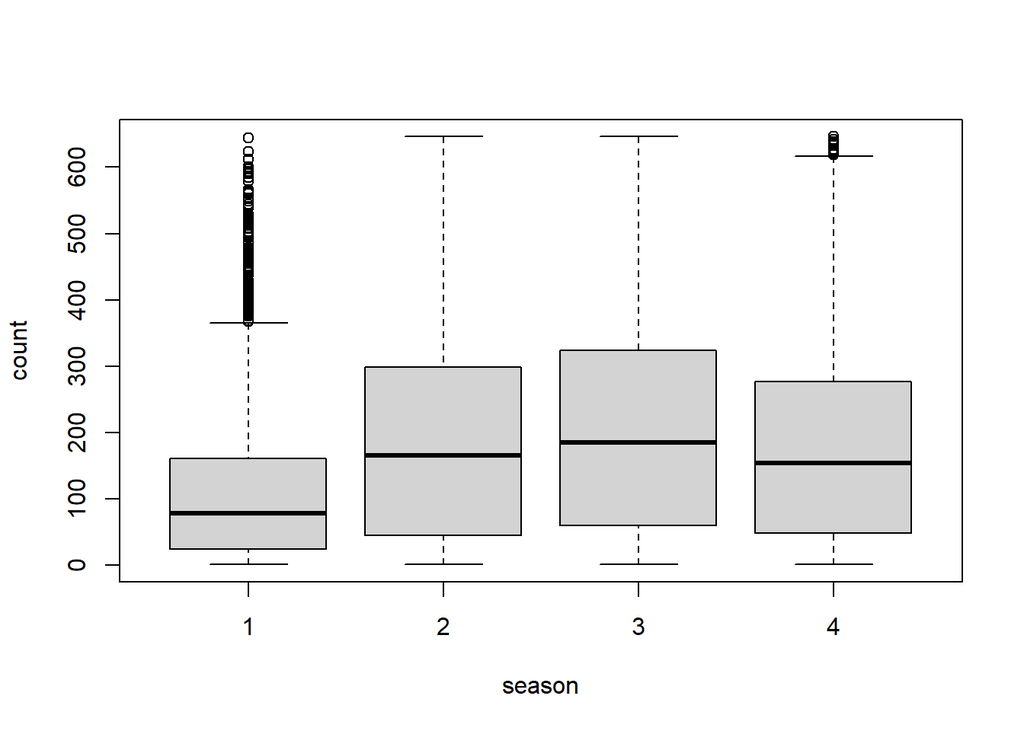

```r
boxplot(count~season)
```

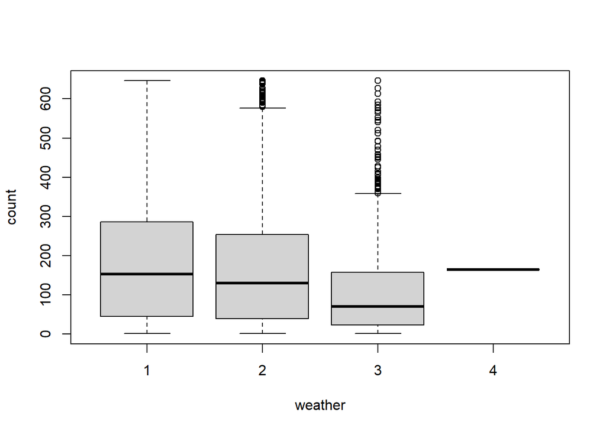

```r
boxplot(count~weather)
```

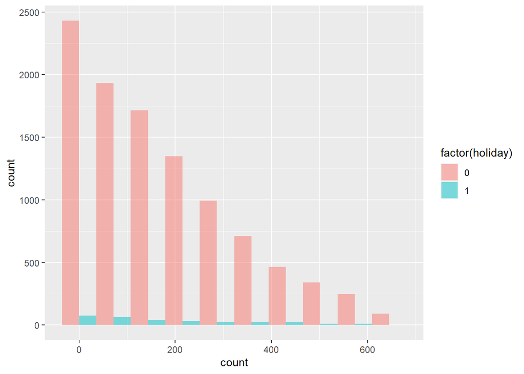

```r
library(ggplot2)
ggplot(data = data) + geom_histogram(aes(x=count,fill=factor(holiday)),bins=10, position = "dodge",alpha = 0.5)
```

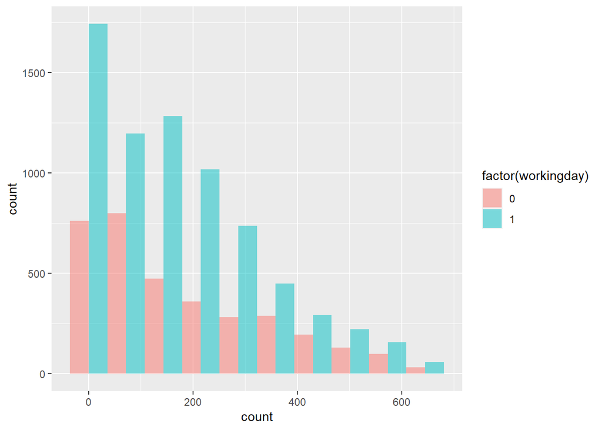

```r
ggplot(data = data) + geom_histogram(aes(x=count,fill=factor(workingday)),bins=10, position = "dodge",alpha = 0.5)
```

We can see that these variables also affect the number of rentals.

Our model is going to use datetime, season, workingday, holiday, weather, registered and casual to predict the number of rentals.

For the poisson regression we will use the package MCMCpack.

For the poisson regression:
$$Y \mid
\lambda \sim \text{Poisson}(\lambda)$$
$$\log \lambda = \beta_0 + \sum_{j=1}^k \beta_j
x_j$$
First we fit a Bayesian Poisson regression model.

```r
library(MCMCpack)
poisson.mcmc = MCMCpoisson(count ~ datetime + season + workingday + holiday + weather + registered + casual,burnin=100, mcmc=1000, data=data)
summary(poisson.mcmc)
```

```
##
## Iterations = 101:1100
## Thinning interval = 1
## Number of chains = 1
## Sample size per chain = 1000
##
## 1. Empirical mean and standard deviation for each variable,
##    plus standard error of the mean:
##
##                  Mean SD Naive SE Time-series SE
## (Intercept)  3.700934  0        0              0
## datetime01  -0.401440  0        0              0
## datetime02  -0.751832  0        0              0
## datetime03  -1.376993  0        0              0
## datetime04  -1.960982  0        0              0
## datetime05  -0.883804  0        0              0
## datetime06   0.240070  0        0              0
## datetime07   0.600112  0        0              0
## datetime08   0.587205  0        0              0
## datetime09   0.748166  0        0              0
## datetime10   0.675505  0        0              0
## datetime11   0.697035  0        0              0
## datetime12   0.729689  0        0              0
## datetime13   0.732565  0        0              0
## datetime14   0.716242  0        0              0
## datetime15   0.731199  0        0              0
## datetime16   0.721171  0        0              0
## datetime17   0.621699  0        0              0
## datetime18   0.638097  0        0              0
## datetime19   0.669965  0        0              0
## datetime20   0.716974  0        0              0
## datetime21   0.680160  0        0              0
## datetime22   0.582725  0        0              0
## datetime23   0.359954  0        0              0
## season2      0.152650  0        0              0
## season3      0.183097  0        0              0
## season4      0.145983  0        0              0
## workingday1 -0.028125  0        0              0
## holiday1    -0.017931  0        0              0
## weather2    -0.006360  0        0              0
```

[output cut: 27 more lines]

```
## datetime19   0.669965  0.669965  0.669965  0.669965  0.669965
## datetime20   0.716974  0.716974  0.716974  0.716974  0.716974
## datetime21   0.680160  0.680160  0.680160  0.680160  0.680160
## datetime22   0.582725  0.582725  0.582725  0.582725  0.582725
## datetime23   0.359954  0.359954  0.359954  0.359954  0.359954
## season2      0.152650  0.152650  0.152650  0.152650  0.152650
## season3      0.183097  0.183097  0.183097  0.183097  0.183097
## season4      0.145983  0.145983  0.145983  0.145983  0.145983
## workingday1 -0.028125 -0.028125 -0.028125 -0.028125 -0.028125
## holiday1    -0.017931 -0.017931 -0.017931 -0.017931 -0.017931
## weather2    -0.006360 -0.006360 -0.006360 -0.006360 -0.006360
## weather3    -0.147662 -0.147662 -0.147662 -0.147662 -0.147662
## weather4     0.186445  0.186445  0.186445  0.186445  0.186445
## registered   0.003702  0.003702  0.003702  0.003702  0.003702
## casual       0.002925  0.002925  0.002925  0.002925  0.002925
```

We can see that casual, registered and weather2 have very small coefficients. We can also see that due to the variable datetime we have created a lot of dummy variables. One possible solution could be grouping the hours in morning, afternoon, evening and night

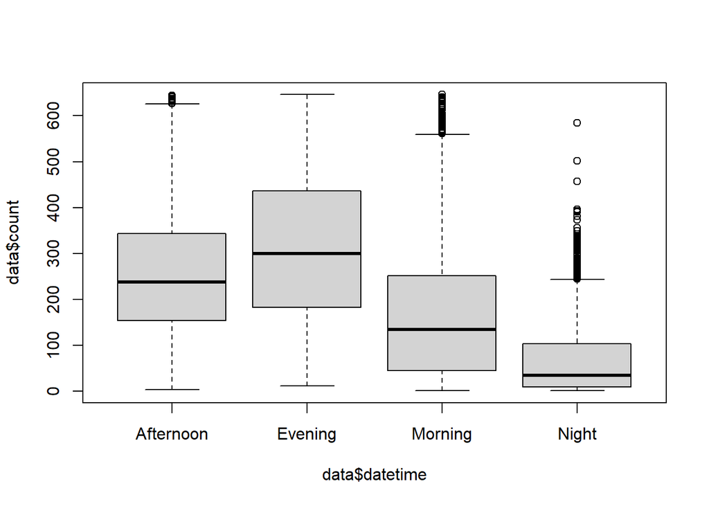

```r
transformHour = function(x){
  if((x>=6)&&(x<=12)){
    x="Morning"
  }
  if((x>12)&&(x<=17)){
    x="Afternoon"
  }
  if((x>17)&&(x<=21)){
    x="Evening"
  }
  if(x<6){
    x="Night"
  }
  if(x==22){
    x="Night"
  }
  if(x==23){
    x="Night"
  }
  if(x==24){
    x="Night"
  }
  return(x)
}
data$datetime=sapply(as.numeric(data$datetime), transformHour)
data$datetime=as.factor(data$datetime)
boxplot(data$count~data$datetime)
```

```r
attach(data)
poisson.mcmc = MCMCpoisson(count ~ datetime + season + workingday + holiday + weather + registered + casual,burnin=100, mcmc=1000, data=data)
summary(poisson.mcmc)
```

```
##
## Iterations = 101:1100
## Thinning interval = 1
## Number of chains = 1
## Sample size per chain = 1000
##
## 1. Empirical mean and standard deviation for each variable,
##    plus standard error of the mean:
##
##                      Mean        SD  Naive SE Time-series SE
## (Intercept)      4.289176 3.254e-03 1.029e-04      7.476e-04
## datetimeEvening -0.103865 2.022e-03 6.393e-05      4.748e-04
## datetimeMorning -0.130461 1.834e-03 5.801e-05      4.039e-04
## datetimeNight   -0.495472 3.463e-03 1.095e-04      9.200e-04
## season2          0.107978 2.225e-03 7.036e-05      4.501e-04
## season3          0.139815 2.189e-03 6.921e-05      3.957e-04
## season4          0.107689 2.073e-03 6.556e-05      4.133e-04
## workingday1     -0.009760 2.018e-03 6.382e-05      4.213e-04
## holiday1        -0.003196 4.228e-03 1.337e-04      1.102e-03
## weather2         0.000823 2.380e-03 7.525e-05      7.146e-04
## weather3        -0.119770 2.354e-03 7.445e-05      4.610e-04
## weather4         0.257318 7.480e-02 2.365e-03      1.667e-02
## registered       0.004153 4.464e-06 1.412e-07      8.336e-07
## casual           0.003454 1.460e-05 4.617e-07      3.462e-06
##
## 2. Quantiles for each variable:
##
##                      2.5%        25%        50%        75%     97.5%
## (Intercept)      4.284966  4.2866877  4.2882400  4.2914590  4.295461
## datetimeEvening -0.107689 -0.1053753 -0.1034142 -0.1025265 -0.100318
## datetimeMorning -0.135462 -0.1315704 -0.1303701 -0.1293794 -0.126880
## datetimeNight   -0.501461 -0.4991131 -0.4953305 -0.4925216 -0.489628
## season2          0.103665  0.1062599  0.1082278  0.1096311  0.111097
## season3          0.135089  0.1384615  0.1401129  0.1421763  0.143694
## season4          0.103547  0.1065418  0.1076934  0.1086738  0.111955
## workingday1     -0.013937 -0.0112071 -0.0100280 -0.0081610 -0.006776
## holiday1        -0.010467 -0.0064202 -0.0026807 -0.0004508  0.005011
## weather2        -0.003733 -0.0006817  0.0006125  0.0022867  0.004826
## weather3        -0.123385 -0.1215932 -0.1194995 -0.1179743 -0.115913
## weather4         0.112289  0.2233095  0.2576803  0.3063222  0.402424
## registered       0.004145  0.0041501  0.0041533  0.0041559  0.004160
## casual           0.003427  0.0034440  0.0034536  0.0034633  0.003482
```

Now we have less dummy variables so we decrease the number of coefficients. We have to check the e convergence of the mcmc chain.

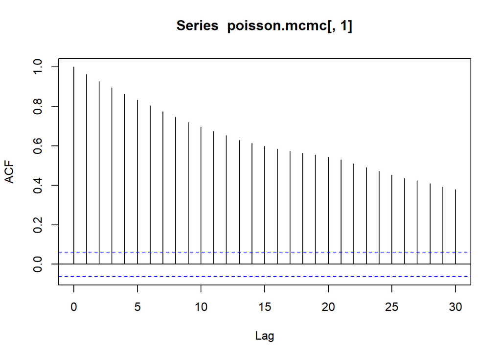

```r
acf(poisson.mcmc[,1])
```

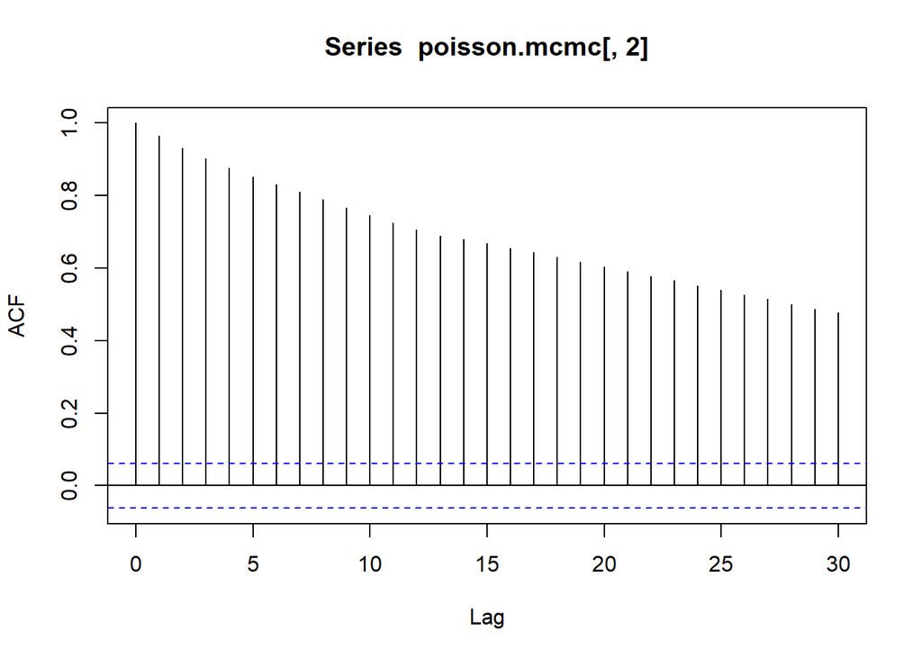

```r
acf(poisson.mcmc[,2])
```

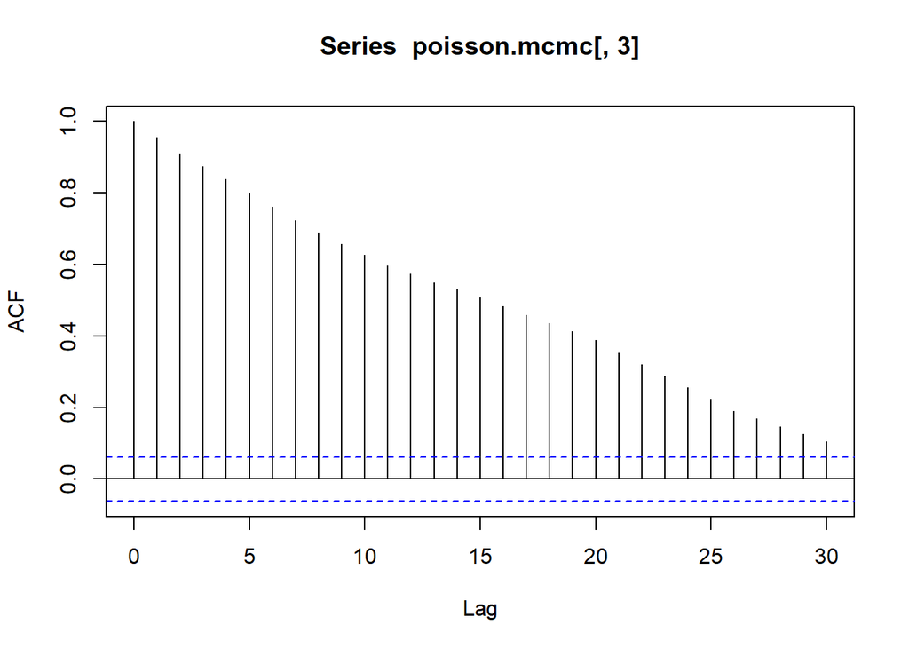

```r
acf(poisson.mcmc[,3])
```

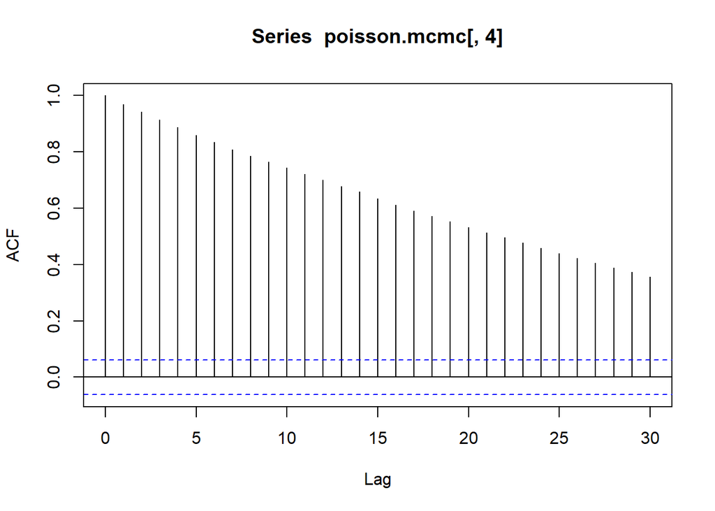

```r
acf(poisson.mcmc[,4])
```

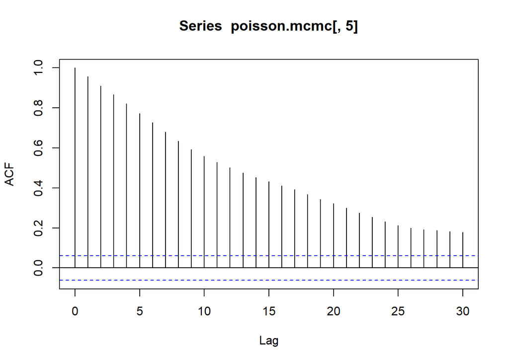

```r
acf(poisson.mcmc[,5])
```

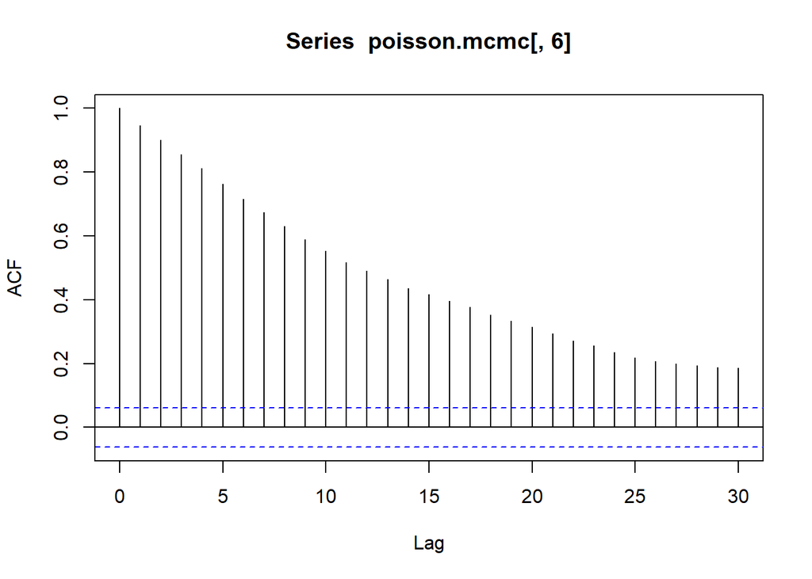

```r
acf(poisson.mcmc[,6])
```

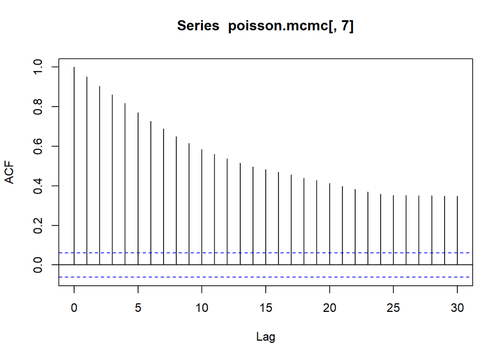

```r
acf(poisson.mcmc[,7])
```

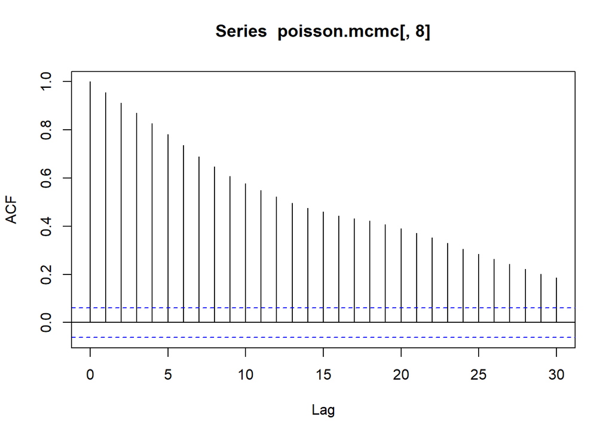

```r
acf(poisson.mcmc[,8])
```

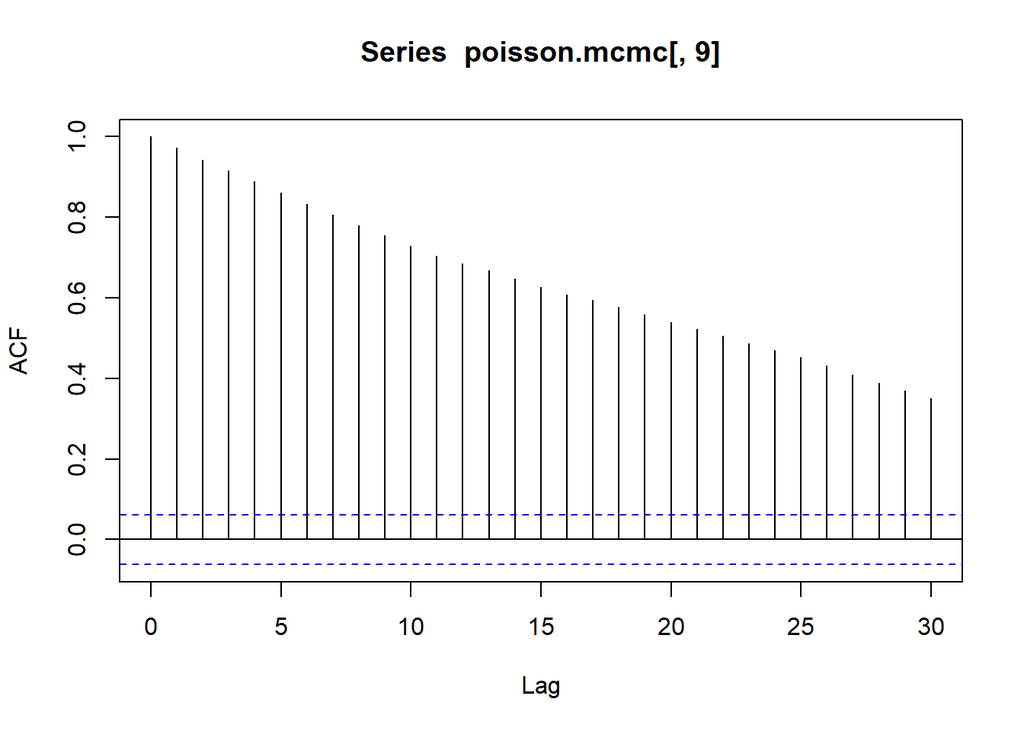

```r
acf(poisson.mcmc[,9])
```

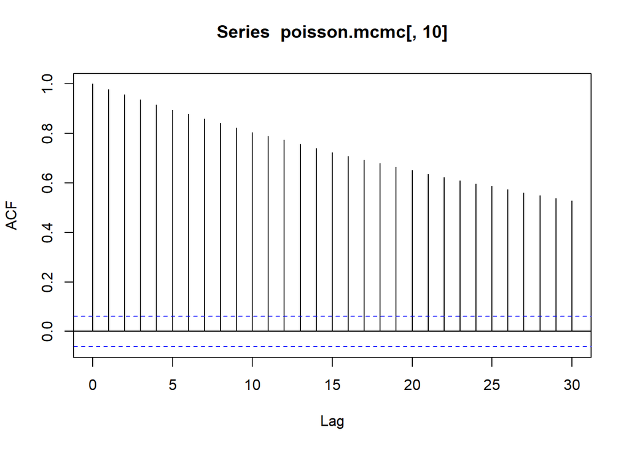

```r
acf(poisson.mcmc[,10])
```

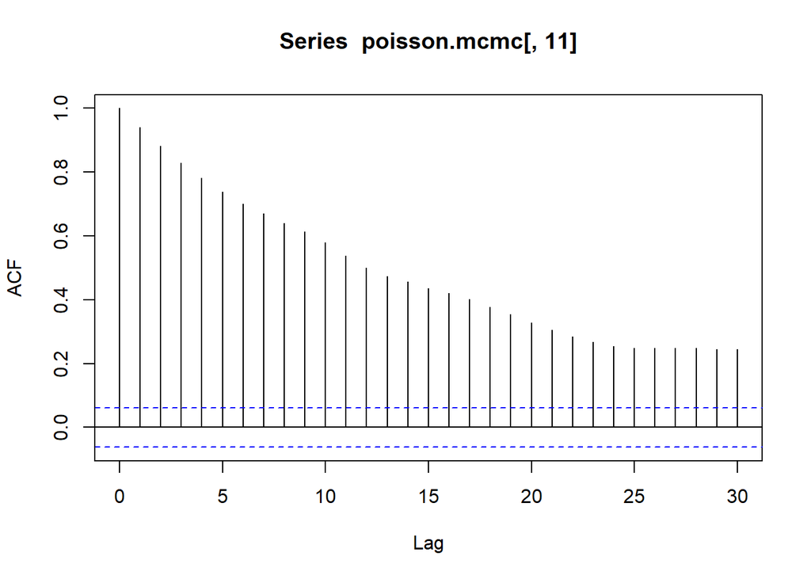

```r
acf(poisson.mcmc[,11])
```

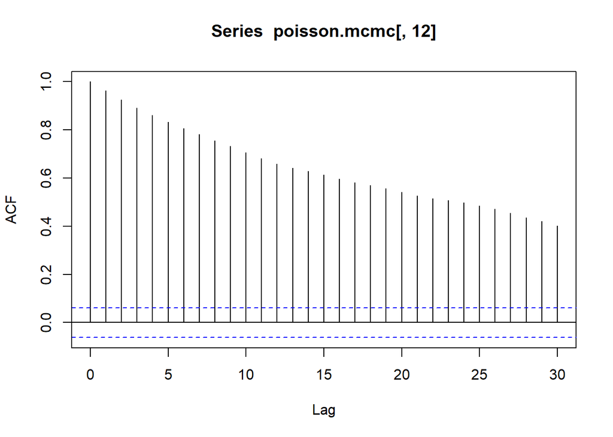

```r
acf(poisson.mcmc[,12])
```

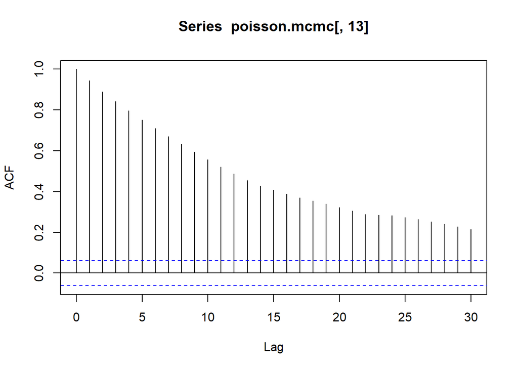

```r
acf(poisson.mcmc[,13])
```

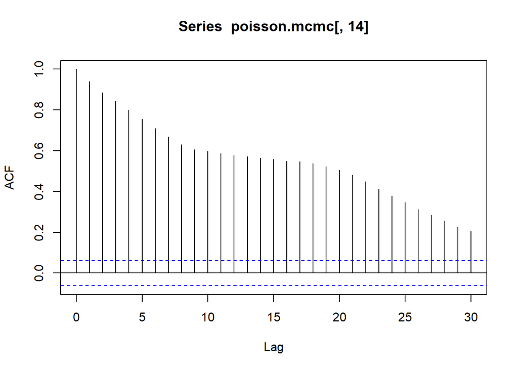

```r
acf(poisson.mcmc[,14])
```

According to the graphs we need to incorporate some thinning in the algorithm.

```r
poisson.mcmc = MCMCpoisson(count ~ datetime + season + workingday + weather + registered + casual + holiday,burnin=1000, mcmc=10000, ,thin = 50, data=data)
summary(poisson.mcmc)
```

```
##
## Iterations = 1001:10951
## Thinning interval = 50
## Number of chains = 1
## Sample size per chain = 200
##
## 1. Empirical mean and standard deviation for each variable,
##    plus standard error of the mean:
##
##                      Mean        SD  Naive SE Time-series SE
## (Intercept)      4.287805 3.314e-03 2.343e-04      3.138e-04
## datetimeEvening -0.103403 2.138e-03 1.512e-04      2.027e-04
## datetimeMorning -0.130632 2.150e-03 1.520e-04      1.747e-04
## datetimeNight   -0.494544 2.982e-03 2.108e-04      2.932e-04
## season2          0.107922 2.372e-03 1.677e-04      1.586e-04
## season3          0.139756 2.278e-03 1.610e-04      1.920e-04
## season4          0.107763 2.334e-03 1.650e-04      1.983e-04
## workingday1     -0.009434 2.139e-03 1.512e-04      1.787e-04
## weather2         0.001101 1.785e-03 1.262e-04      1.746e-04
## weather3        -0.119608 3.444e-03 2.435e-04      3.116e-04
## weather4         0.241652 7.845e-02 5.547e-03      8.068e-03
## registered       0.004154 6.656e-06 4.707e-07      4.957e-07
## casual           0.003457 1.936e-05 1.369e-06      1.875e-06
## holiday1        -0.003792 4.479e-03 3.167e-04      3.941e-04
##
## 2. Quantiles for each variable:
##
##                      2.5%        25%       50%        75%     97.5%
## (Intercept)      4.281842  4.2854569  4.287826  4.2900403  4.293595
## datetimeEvening -0.107551 -0.1048323 -0.103467 -0.1021145 -0.098777
## datetimeMorning -0.134735 -0.1321266 -0.130627 -0.1290522 -0.126575
## datetimeNight   -0.500302 -0.4968320 -0.494587 -0.4922902 -0.489127
## season2          0.103734  0.1063641  0.107702  0.1095823  0.112692
## season3          0.135149  0.1382205  0.139982  0.1414547  0.143922
## season4          0.102425  0.1062382  0.107698  0.1094103  0.111838
## workingday1     -0.013461 -0.0108748 -0.009483 -0.0079153 -0.005167
## weather2        -0.002242 -0.0002566  0.001235  0.0022881  0.004266
## weather3        -0.125914 -0.1220068 -0.119831 -0.1174804 -0.112649
## weather4         0.080385  0.2001401  0.238872  0.2869851  0.413843
## registered       0.004142  0.0041501  0.004155  0.0041594  0.004167
## casual           0.003422  0.0034448  0.003455  0.0034708  0.003497
## holiday1        -0.011831 -0.0073857 -0.003780 -0.0009619  0.005257
```

We can see that the quantile of weather2 and holiday1 contains 0

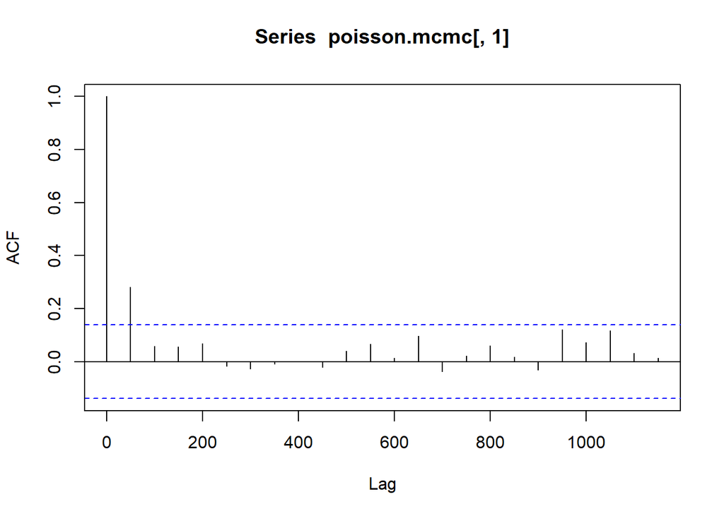

```r
acf(poisson.mcmc[,1])
```

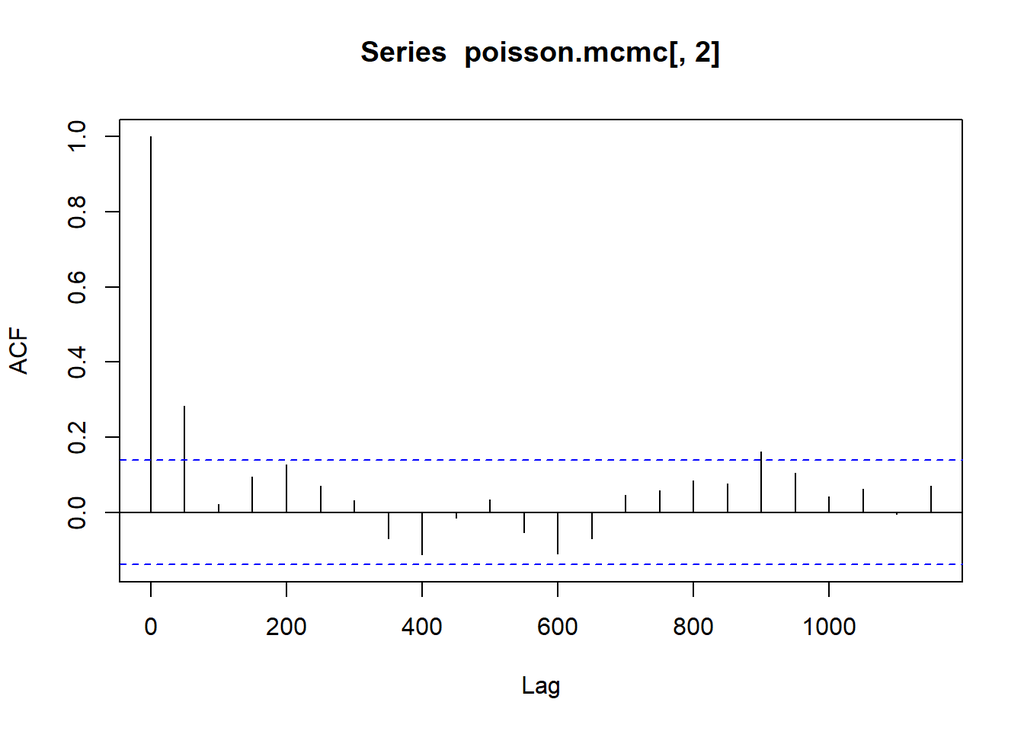

```r
acf(poisson.mcmc[,2])
```

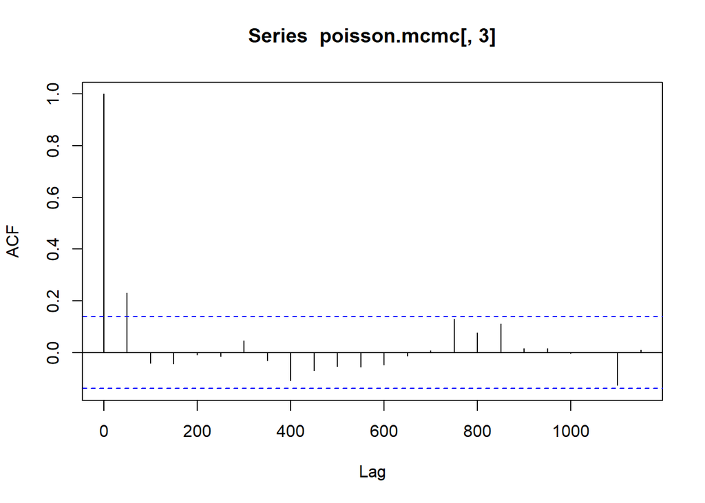

```r
acf(poisson.mcmc[,3])
```

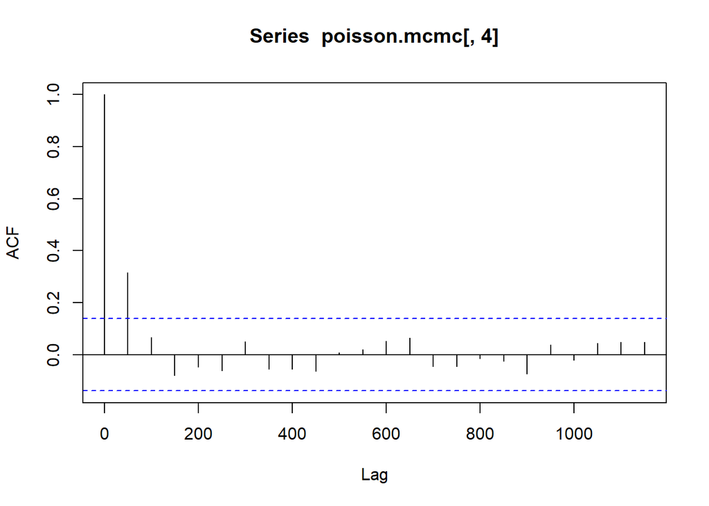

```r
acf(poisson.mcmc[,4])
```

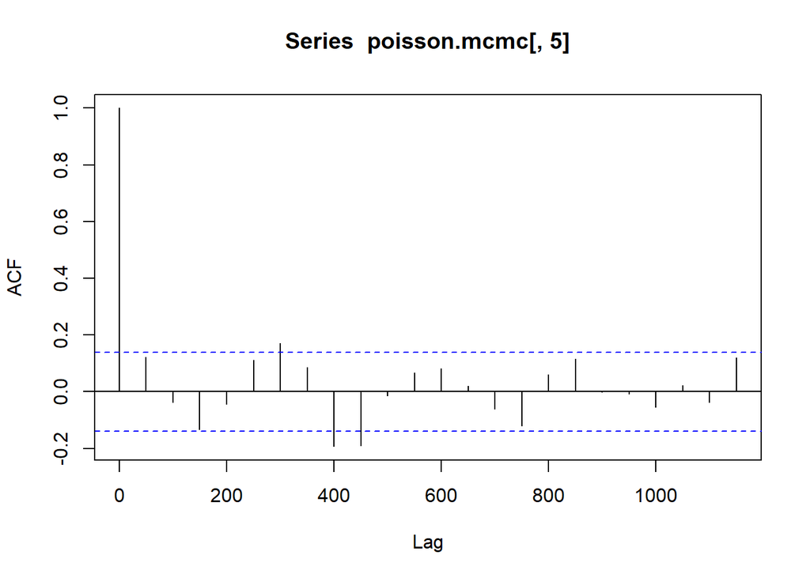

```r
acf(poisson.mcmc[,5])
```

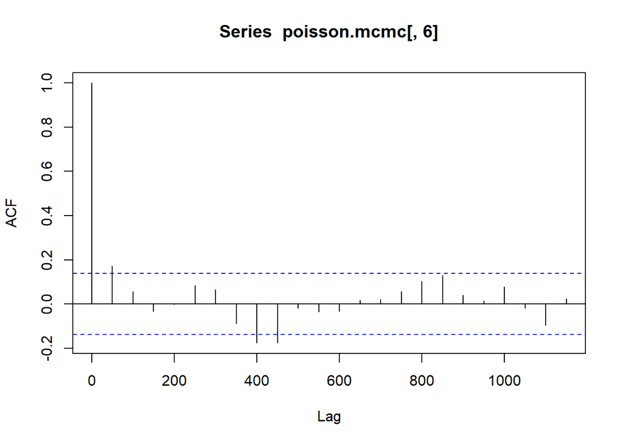

```r
acf(poisson.mcmc[,6])
```